# survey for cool white dwarfs and the age of the Galactic disc | Monthly Notices of the Royal Astronomical Society | Oxford Academic

## 9 Conclusions

We may summarize our results as follows.

- (i)

  Using a large collection of COSMOS/SuperCOSMOS digitized Schmidt plate data in ESO/SERC field 287, we have extracted a sample of proper motion objects. Number counts indicate that this sample is complete down to the survey proper motion limit, which was chosen with care to exclude contaminant spurious proper motion measures.
- (ii)

## Acknowledgments

We thank M. Wood and E. García-Berro for access to theoretical WDLFs, and P. Bergeron, P. Hauschildt and B. Hansen for supplying model atmosphere predictions. Thanks are also due to S. Ryan for supplying lists of subdwarfs, and to Andy Taylor for useful discussions concerning statistics. This work would not have been possible without the time and expertise of the SuperCOSMOS and UK Schmidt Library staff. Particular thanks are due to Harvey MacGillivray, Mike Read and Sue Tritton. Richard Knox acknowledges a PPARC postgraduate studentship.

## References

S. M.

MacGillivray

H. T.

Thanisch

P. F.

,

1990

,

MNRAS

,

247

,

311

Bergeron

P.

Wesemael

F.

Beauchamp

A.

,

1995

,

PASP

,

107

,

1047

[Crossref](http://dx.doi.org/10.1086/133661)

[Search ADS](http://adsabs.harvard.edu/cgi-bin/basic_connect?qsearch=10.1086%2F133661)

Bergeron

P.

Ruiz

M. T.

Leggett

S. K.

,

1997

,

ApJS

,

108

,

339

(BRL)

[Crossref](http://dx.doi.org/10.1086/apjs.1997.108.issue-1)

[Search ADS](http://adsabs.harvard.edu/cgi-bin/basic_connect?qsearch=10.1086%2Fapjs.1997.108.issue-1)

Burkert

A.

Truran

J. W.

Hensler

G.

,

1992

,

ApJ

,

391

,

651

[Crossref](http://dx.doi.org/10.1086/171378)

[Search ADS](http://adsabs.harvard.edu/cgi-bin/basic_connect?qsearch=10.1086%2F171378)

Evans

D. W.

,

1989

,

A&AS

,

78

,

249

Evans

D. W.

,

1992

,

MNRAS

,

255

,

521

[Crossref](http://dx.doi.org/10.1093/mnras/255.3.521)

[Search ADS](http://adsabs.harvard.edu/cgi-bin/basic_connect?qsearch=10.1093%2Fmnras%2F255.3.521)

Festin

L.

,

1998

,

A&A

,

336

,

883

Fleming

T. A.

Liebert

J.

Green

R. F.

,

1986

,

ApJ

,

308

,

176

[Crossref](http://dx.doi.org/10.1086/164488)

[Search ADS](http://adsabs.harvard.edu/cgi-bin/basic_connect?qsearch=10.1086%2F164488)

Freedman

W. L.

,

1999

, in

Turok

N.

, ed.,

Proceedings for ‘Critical Dialogs in Cosmology’

,

World Scientific Publishing

, p.

92

Google Scholar

[Google Preview](https://www.google.com/search?q=Proceedings%20for%20%E2%80%98Critical%20Dialogs%20in%20Cosmology%E2%80%99&btnG=Search+Books&tbm=bks&tbo=1)

[WorldCat](https://www.worldcat.org/search?q=ti:Proceedings%20for%20%E2%80%98Critical%20Dialogs%20in%20Cosmology%E2%80%99&qt=advanced&dblist=638)

[COPAC](http://copac.ac.uk/search?ti=Proceedings%20for%20%E2%80%98Critical%20Dialogs%20in%20Cosmology%E2%80%99)

García-Berro

E.

Isern

J.

Hernanz

M.

,

1997

,

MNRAS

,

289

,

973

[Crossref](http://dx.doi.org/10.1093/mnras/289.4.973)

[Search ADS](http://adsabs.harvard.edu/cgi-bin/basic_connect?qsearch=10.1093%2Fmnras%2F289.4.973)

Giclas

H. L.

Burnham

R.

Thomas

N. G.

,

1971

,

Lowell Proper Motion Survey, Northern Hemisphere Catalogue

.

Flagstaff

:

Lowell

Giclas

H. L.

Burnham

R.

Thomas

N. G.

,

1978

,

Lowell Proper Motion Survey, Southern Hemisphere Catalogue Lowell Obs

. Bull. 164, Vol

VIII

, p.

89

Greenstein

J. L.

Liebert

J.

,

1990

,

ApJ

,

360

,

662

[Crossref](http://dx.doi.org/10.1086/169153)

[Search ADS](http://adsabs.harvard.edu/cgi-bin/basic_connect?qsearch=10.1086%2F169153)

Hambly

N. C.

Smartt

S. J.

Hodgkin

S. T.

,

1997

,

ApJ

,

489

,

L157

[Crossref](http://dx.doi.org/10.1086/316797)

[Search ADS](http://adsabs.harvard.edu/cgi-bin/basic_connect?qsearch=10.1086%2F316797)

Hambly

N. C.

Miller

L.

MacGillivray

H. T.

Herd

J. T.

Cormack

W. A.

,

1998

,

MNRAS

,

298

,

897

[Crossref](http://dx.doi.org/10.1046/j.1365-8711.1998.01669.x)

[Search ADS](http://adsabs.harvard.edu/cgi-bin/basic_connect?qsearch=10.1046%2Fj.1365-8711.1998.01669.x)

Hansen

B. M. S.

,

1998

,

Nat

,

394

,

860

[Crossref](http://dx.doi.org/10.1038/29710)

[Search ADS](http://adsabs.harvard.edu/cgi-bin/basic_connect?qsearch=10.1038%2F29710)

Hauschildt

P. H.

Allard

F.

Baron

E.

,

1999

,

ApJ

,

512

,

377

[Crossref](http://dx.doi.org/10.1086/apj.1999.512.issue-1)

[Search ADS](http://adsabs.harvard.edu/cgi-bin/basic_connect?qsearch=10.1086%2Fapj.1999.512.issue-1)

Hawkins

M. R. S.

,

1986

,

MNRAS

,

223

,

845

[Crossref](http://dx.doi.org/10.1093/mnras/223.4.845)

[Search ADS](http://adsabs.harvard.edu/cgi-bin/basic_connect?qsearch=10.1093%2Fmnras%2F223.4.845)

Hawkins

M. R. S.

,

1991

, in IAU Commission 9: Working Group on Wide-Field Imaging, Newsletter No. 1, 23

Hawkins

M. R. S.

Bessell

M. S.

,

1988

,

MNRAS

,

234

,

177

[Crossref](http://dx.doi.org/10.1093/mnras/234.2.177)

[Search ADS](http://adsabs.harvard.edu/cgi-bin/basic_connect?qsearch=10.1093%2Fmnras%2F234.2.177)

Hawkins

M. R. S.

Ducourant

C.

Jones

H. R. A.

Rapaport

M.

,

1998

,

MNRAS

,

294

,

505

[Crossref](http://dx.doi.org/10.1111/j.1365-8711.1998.01294.x)

[Search ADS](http://adsabs.harvard.edu/cgi-bin/basic_connect?qsearch=10.1111%2Fj.1365-8711.1998.01294.x)

Hernanz

M.

García-Berro

E.

Isern

J.

Mochkovitch

R.

Segretain

L.

Chabrier

G.

,

1994

,

ApJ

,

434

,

652

[Crossref](http://dx.doi.org/10.1086/174767)

[Search ADS](http://adsabs.harvard.edu/cgi-bin/basic_connect?qsearch=10.1086%2F174767)

Isern

J.

García-Berro

E.

Hernanz

M.

Mochkovitch

R.

Torres

S.

,

1998

,

ApJ

,

503

,

239

[Crossref](http://dx.doi.org/10.1086/apj.1998.503.issue-1)

[Search ADS](http://adsabs.harvard.edu/cgi-bin/basic_connect?qsearch=10.1086%2Fapj.1998.503.issue-1)

Jimenez

R.

Flynn

C.

Kotoneva

E.

,

1998

,

MNRAS

,

299

,

515

[Crossref](http://dx.doi.org/10.1046/j.1365-8711.1998.01787.x)

[Search ADS](http://adsabs.harvard.edu/cgi-bin/basic_connect?qsearch=10.1046%2Fj.1365-8711.1998.01787.x)

Kemp

S. N.

Meaburn

J.

,

1993

,

A&A

,

274

,

19

Knox

R. A.

Hambly

N. C.

Hawkins

M. R. S.

MacGillivray

H. T.

,

1998

,

MNRAS

,

297

,

839

[Crossref](http://dx.doi.org/10.1046/j.1365-8711.1998.01558.x)

[Search ADS](http://adsabs.harvard.edu/cgi-bin/basic_connect?qsearch=10.1046%2Fj.1365-8711.1998.01558.x)

Leggett

S. K.

Ruiz

M. T.

Bergeron

P.

,

1998

,

ApJ

,

497

,

294

(LRB)

[Crossref](http://dx.doi.org/10.1086/apj.1998.497.issue-1)

[Search ADS](http://adsabs.harvard.edu/cgi-bin/basic_connect?qsearch=10.1086%2Fapj.1998.497.issue-1)

Liebert

J.

Dahn

C. C.

Monet

D. G.

,

1988

,

ApJ

,

332

,

891

(LDM)

[Crossref](http://dx.doi.org/10.1086/166699)

[Search ADS](http://adsabs.harvard.edu/cgi-bin/basic_connect?qsearch=10.1086%2F166699)

Luyten

W. J.

,

1969

,

Proper Motion Survey with the 48-inch Schmidt Telescope XXI

. Univ. Minnesota

Luyten

W. J.

,

1970

,

White Dwarfs

. Univ. Minnesota

Luyten

W. J.

,

1974

,

Proper Motion Survey with the 48-inch Schmidt Telescope XXXVIII

. Univ. Minnesota

Luyten

W. J.

,

1979a

,

Proper Motion Survey with the 48-inch Schmidt Telescope LII

. Univ. Minnesota

Luyten

W. J.

,

1979b

,

LHS Catalogue

. Univ. Minnesota

MacGillivray

H. T.

Stobie

R. S.

,

1984

,

Vistas Astron.

,

27

,

433

Crossref

Search ADS

Monet

D. G.

et al. ,

1992

,

AJ

,

103

,

638

[Crossref](http://dx.doi.org/10.1086/116091)

[Search ADS](http://adsabs.harvard.edu/cgi-bin/basic_connect?qsearch=10.1086%2F116091)

Oswalt

T. D.

Smith

J. A.

,

1995

, in

Koester

D.

Werner

K.

, eds,

White Dwarfs

.

Springer

,

Berlin

, p.

24

[Google Scholar](https://scholar.google.com/scholar_lookup?title=White%20Dwarfs&author=T.%20D.%20Oswalt&author=J.%20A.%20Smith&author=D.%20Koester&author=K.%20Werner&publication_year=1995&book=White%20Dwarfs)

[Google Preview](https://www.google.com/search?q=White%20Dwarfs&btnG=Search+Books&tbm=bks&tbo=1)

[WorldCat](https://www.worldcat.org/search?q=ti:White%20Dwarfs&qt=advanced&dblist=638)

[COPAC](http://copac.ac.uk/search?ti=White%20Dwarfs)

Oswalt

T. D.

Smith

J.A

Wood

M. A.

Hintzen

P.

,

1996

,

Nat

,

382

,

692

(OSWH)

[Crossref](http://dx.doi.org/10.1038/382692a0)

[Search ADS](http://adsabs.harvard.edu/cgi-bin/basic_connect?qsearch=10.1038%2F382692a0)

Pitts

E.

Tayler

R. J.

,

1992

,

MNRAS

,

255

,

557

[Crossref](http://dx.doi.org/10.1093/mnras/255.4.557)

[Search ADS](http://adsabs.harvard.edu/cgi-bin/basic_connect?qsearch=10.1093%2Fmnras%2F255.4.557)

Ruiz

M. T.

Takamiya

M. Y.

,

1995

,

AJ

,

109

,

2817

[Crossref](http://dx.doi.org/10.1086/117488)

[Search ADS](http://adsabs.harvard.edu/cgi-bin/basic_connect?qsearch=10.1086%2F117488)

Ruiz

M. T.

Bergeron

P.

Leggett

S. K.

Anguita

C.

,

1995

,

ApJ

,

455

,

L159

[Crossref](http://dx.doi.org/10.1086/309845)

[Search ADS](http://adsabs.harvard.edu/cgi-bin/basic_connect?qsearch=10.1086%2F309845)

Ryan

S. G.

,

1989

,

AJ

,

98

,

1693

[Crossref](http://dx.doi.org/10.1086/115256)

[Search ADS](http://adsabs.harvard.edu/cgi-bin/basic_connect?qsearch=10.1086%2F115256)

Schmidt

M.

,

1959

,

ApJ

,

129

,

243

[Crossref](http://dx.doi.org/10.1086/146614)

[Search ADS](http://adsabs.harvard.edu/cgi-bin/basic_connect?qsearch=10.1086%2F146614)

Schmidt

M.

,

1968

,

ApJ

,

151

,

393

[Crossref](http://dx.doi.org/10.1086/149446)

[Search ADS](http://adsabs.harvard.edu/cgi-bin/basic_connect?qsearch=10.1086%2F149446)

Schmidt

M.

,

1975

,

ApJ

,

202

,

22

[Crossref](http://dx.doi.org/10.1086/153949)

[Search ADS](http://adsabs.harvard.edu/cgi-bin/basic_connect?qsearch=10.1086%2F153949)

Schwartzenberg

J. M.

Phillipps

S.

Parker

Q. A.

,

1996

,

A&AS

,

117

,

179

[Crossref](http://dx.doi.org/10.1051/aas:1996149)

[Search ADS](http://adsabs.harvard.edu/cgi-bin/basic_connect?qsearch=10.1051%2Faas:1996149)

Stobie

R. S.

Ishida

K.

Peacock

J. A.

,

1989

,

MNRAS

,

238

,

709

[Crossref](http://dx.doi.org/10.1093/mnras/238.3.709)

[Search ADS](http://adsabs.harvard.edu/cgi-bin/basic_connect?qsearch=10.1093%2Fmnras%2F238.3.709)

Tinney

C. G.

Reid

I. N.

Mould

J. R.

,

1993

,

ApJ

,

414

,

254

[Crossref](http://dx.doi.org/10.1086/173074)

[Search ADS](http://adsabs.harvard.edu/cgi-bin/basic_connect?qsearch=10.1086%2F173074)

vandenberg

D. A.

,

1998

, in

Bedding

T. R.

Booth

A. J.

Davis

J.

, eds, Proc. IAU Symp. 189, Fundamental Stellar Properties:

The Interaction between Observation and Theory

.

Kluwer

,

Dordrecht

, p.

439

Google Scholar

[Google Preview](https://www.google.com/search?q=The%20Interaction%20between%20Observation%20and%20Theory&btnG=Search+Books&tbm=bks&tbo=1)

[WorldCat](https://www.worldcat.org/search?q=ti:The%20Interaction%20between%20Observation%20and%20Theory&qt=advanced&dblist=638)

[COPAC](http://copac.ac.uk/search?ti=The%20Interaction%20between%20Observation%20and%20Theory)

Véron

P.

Hawkins

M. R. S.

,

1995

,

A&A

,

296

,

665

Winget

D. E.

Hansen

C. J.

Liebert

J.

van Horn

H. M.

Fontaine

G.

Nather

R. E.

Kepler

S. O.

Lamb

D. Q.

,

1987

,

ApJ

,

315

,

L77

[Crossref](http://dx.doi.org/10.1086/184864)

[Search ADS](http://adsabs.harvard.edu/cgi-bin/basic_connect?qsearch=10.1086%2F184864)

Wood

M. A.

,

1992

,

ApJ

,

386

,

539

[Crossref](http://dx.doi.org/10.1086/171038)

[Search ADS](http://adsabs.harvard.edu/cgi-bin/basic_connect?qsearch=10.1086%2F171038)

Wood

M. A.

,

1995

, in

Koester

D.

Werner

K.

, eds,

White Dwarfs

.

Springer

,

Berlin

, p.

41

[Google Scholar](https://scholar.google.com/scholar_lookup?title=White%20Dwarfs&author=M.%20A.%20Wood&author=D.%20Koester&author=K.%20Werner&publication_year=1995&book=White%20Dwarfs)

[Google Preview](https://www.google.com/search?q=White%20Dwarfs&btnG=Search+Books&tbm=bks&tbo=1)

[WorldCat](https://www.worldcat.org/search?q=ti:White%20Dwarfs&qt=advanced&dblist=638)

[COPAC](http://copac.ac.uk/search?ti=White%20Dwarfs)

Wood

M. A.

Oswalt

T. D.

,

1998

,

ApJ

,

497

,

870

[Crossref](http://dx.doi.org/10.1086/apj.1998.497.issue-2)

[Search ADS](http://adsabs.harvard.edu/cgi-bin/basic_connect?qsearch=10.1086%2Fapj.1998.497.issue-2)

IRAF is distributed by the National Optical Astronomy Observatories, which is operated by the Association of Universities for Research in Astronomy Inc., under contract with the National Science Foundation of the United States of America.

### Appendix

#### Appendix A:Reduced Proper Motion Diagrams

The reduced proper motion (RPM) is defined by

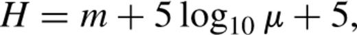

(A1)

where m is the apparent magnitude, and μ the proper motion. A reduced proper motion diagram (RPMD) is a plot of colour against RPM. It is a powerful way of combining proper motions and photometry to distinguish stellar population groups. Equation (A1) can be rewritten using the relationships *m*=*M*−5+5log*d* and μ=*V*<sub>T</sub>/4.74*d* to give

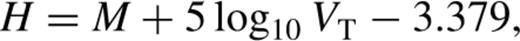

(A2)

where M is the absolute magnitude, *V*<sub>T</sub> the transverse velocity (in km s<sup>−1</sup>), and d the distance. Since M and *V*<sub>T</sub> are both intrinsic properties of the star, so too is H.

To see the significance of H, suppose that every star had an identical *V*<sub>T</sub>; H would then clearly be simply M plus a constant, and the distribution of a particular population group in H at a particular colour would depend solely on the spread of the populations’ colour-magnitude relation at that colour. Of course, there is a distribution in 5log<sub>10</sub>*V*<sub>T</sub> for each population, but since the tangential velocities are distributed around a most probable value, the RPM serves as an estimate of M, i.e., *M*=*a*+*bH* (a and b are constants). The resulting locus for each population in the RPMD is then the convolution of its colour-magnitude distribution with its 5log<sub>10</sub>*V*<sub>T</sub> distribution over the diagrams colour range. To allow population discrimination in some colour region, we therefore only require that the various population loci do not overlap significantly in that region of the RPMD. In effect, the RPMD is analogous to the Hertsprung-Russell diagram, and in both plots the white dwarf population is quite distinct in most colours.

[figure not shown]

[figure not shown]